# Homework2-PracticeAbstract

2023-01-23

An experiment was conducted to (a) investigate the effects of a drug, human granulocyte colony stimulating factor (gcsf), on the growth of certain cells in human blood and (b) to determine if the effect of the drug is influenced by age. Thirty-eight subjects were randomized to one of three dose levels of gcsf: 0, 30, or 300 micrograms. Blood samples were collected at three times: prior to drug administration, one day after the drug treatment, and five days after treatment. The number of cell colonies per ml of blood (colony forming units) was recorded.

The data are provided in an Excel file gcsf.xlsx on the class website. The study variables are: id: subject id number gcsf: drug dose (in 0, 30, or 300 micrograms) age: age of subject in years cfu0: day 0 colony forming units (baseline) cfu1: day 1 colony forming units cfu5: day 5 colony forming units

```r
#read in the data
library(ggplot2)
library(readxl)
library(knitr)
library(car)
library(rstatix)
library(ggpubr)
library(lme4)
library(lmerTest)
library(effects)
data_wide <- read_excel('gcsf.xlsx', sheet = 'gcsfWide')
data_long <- read_excel('gcsf.xlsx', sheet = 'gcsfLong')
```

```r
#look at summary statistics
summary(data_long)
```

```
##        id            days        gcsf            age             cfu
##  Min.   : 1.0   Min.   :0   Min.   :  0.0   Min.   :20.00   Min.   : -1.00
##  1st Qu.:10.0   1st Qu.:0   1st Qu.:  0.0   1st Qu.:23.00   1st Qu.:  2.00
##  Median :19.5   Median :1   Median : 30.0   Median :50.00   Median :  8.50
##  Mean   :19.5   Mean   :2   Mean   :121.6   Mean   :48.58   Mean   : 38.72
##  3rd Qu.:29.0   3rd Qu.:5   3rd Qu.:300.0   3rd Qu.:74.00   3rd Qu.: 29.75
##  Max.   :38.0   Max.   :5   Max.   :300.0   Max.   :79.00   Max.   :749.00
```

```r
#change id, gcsf, and days to factor variables
data_long$gcsf_c <- as.factor(data_long$gcsf)
data_long$days_c <- as.factor(data_long$days)
data_long$id_c <- as.factor(data_long$id)

#create label variable for plot
data_long$day_label <- NA
data_long$day_label[data_long$days == 0] <- 'Day 0'
data_long$day_label[data_long$days == 1] <- 'Day 1'
data_long$day_label[data_long$days == 5] <- 'Day 5'

data_long$dose_label <- NA
data_long$dose_label[data_long$gcsf == 0] <- '0 micrograms'
data_long$dose_label[data_long$gcsf == 30] <- '30 micrograms'
data_long$dose_label[data_long$gcsf == 300] <- '300 micrograms'
```

With this data, a repeated measure ANCOVA could be fit to test for difference in means with the cfu as the output variable and gcsf, age, time, and id as input variables. The assumptions of repeated measures ANCOVA include normality of the groups.

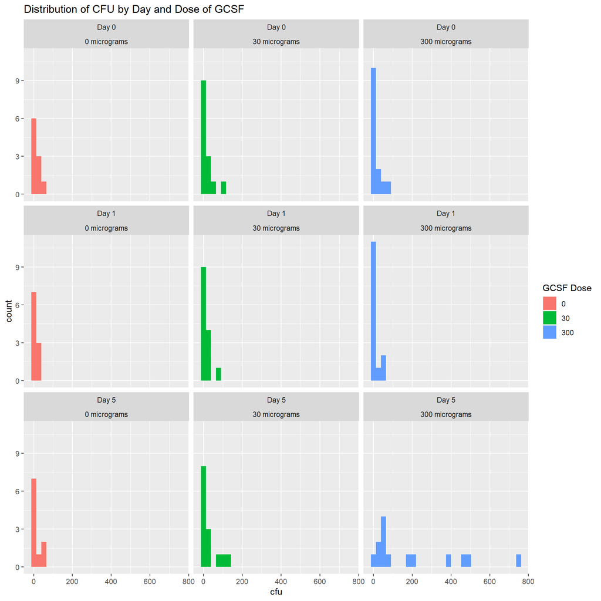

```r
#look at distribution of cfu by treatment group
ggplot(aes(x = cfu, fill = gcsf_c), data = as.data.frame(data_long)) +
  geom_histogram() +
  facet_wrap(c('day_label','dose_label')) +
  ggtitle("Distribution of CFU by Day and Dose of GCSF") +
  labs(fill = "GCSF Dose")
```

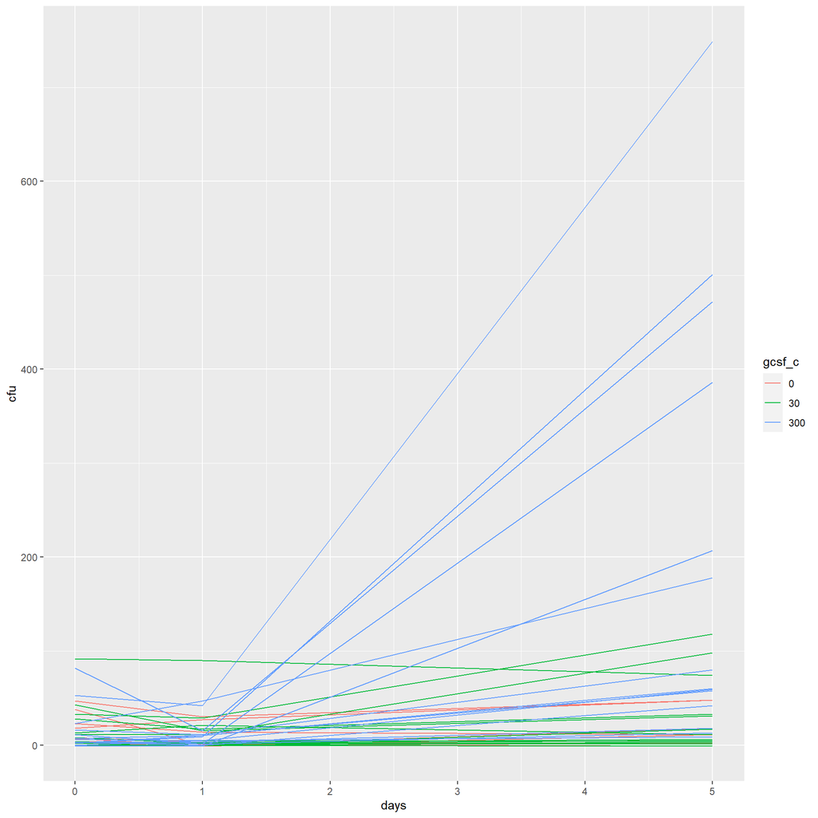

```r
#spaghetti plot
ggplot(data = data_long, aes(x = days, y = cfu, group = id, colour = gcsf_c)) + geom_line()
```

```r
#get summary stats
summary_stats <- data_long %>%
  group_by(days, gcsf) %>%
  get_summary_stats(cfu, type = "median_iqr")

overall <- data_long %>% group_by(gcsf) %>% get_summary_stats(cfu, type = "median_iqr")

summary_stats[10:12,] <- data.frame(days = rep(NA,3), overall)


#get summary of age by treatment group
summary_age<- data_long %>%
  group_by(gcsf) %>%
  get_summary_stats(age, type = "median_iqr")
```